# Math 120 Week 05

Prof Miller

05 March, 2021

# Monday Mar 1

## Effects of outliers (ctd)

More examples.

### Ex: mpg data. Predict cty mpg based on displ

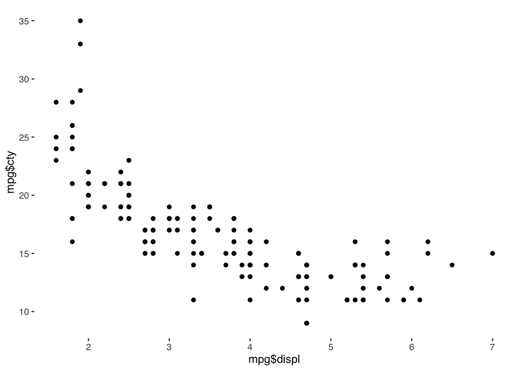

```r
qplot(mpg$displ, mpg$cty)
```

```r
cor(mpg$cty, mpg$displ)
```

```
## [1] -0.798524
```

What if the following outlier is added: x=20L, y=100mpg

Before outlier:  
After outerlier:

Moral of the story:

### Ex: same mpg example (x=displ, y=cty).

Try the following outlier: x=5, y=70.

Correl before:  
Correl after:

Some effect, but not drastic. Why?

Answer: Leverage.

-Outliers with x-values that far outside the range of observations ….

-Outliers with x-vals that are within the range of observations …

Moral of the story: doesn’t change much.

### Final example: mpg data, x=cty y=hwy

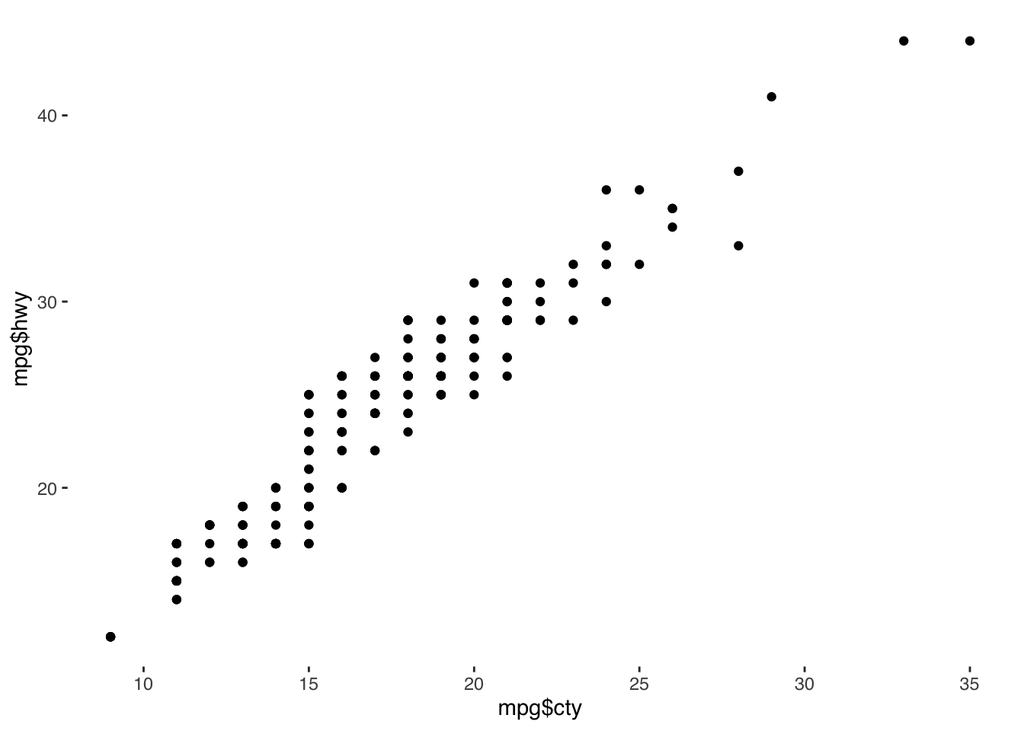

```r
qplot(mpg$cty, mpg$hwy)
```

```r
cor(mpg$cty, mpg$hwy)
```

```
## [1] 0.9559159
```

Outlier: x= 100, y=115.

Correl before:  
Correl after:

Moral of the story

### BIG MORAL OF THE STORY:

Outliers could do anything! Have to look!

## Analyzing the model (ctd)

So far: outliers

Now: residuals.

Recall: for an observation x,

```
resid =
```

(the vertical distance between a point and the line)

Think: residuals are errors!

As always, visualize first! Tool: residual plot!

```
x-axis:
y-axis:
```

Example: mpg x=displ y=cty

Original:

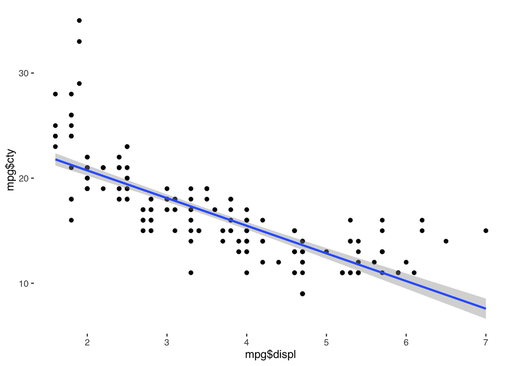

```r
qplot(mpg$displ, mpg$cty)+geom_smooth(method="lm")
```

Residual plot:

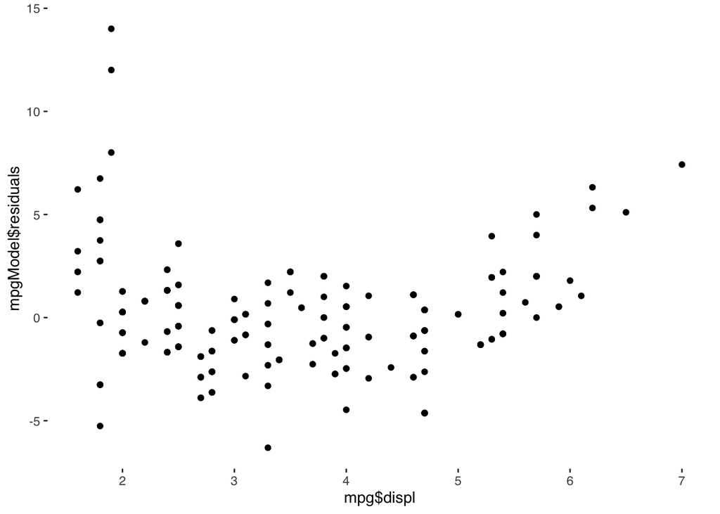

```r
mpgModel <- lm(mpg$cty~mpg$displ)
qplot(mpg$displ, mpgModel$residuals)
```

Qualities of “bad” residuals:

- …
- …

### Examples: mpg x=displ and y=cty

Residual plot shows …

### Example: mpg x=cty and y=hyw

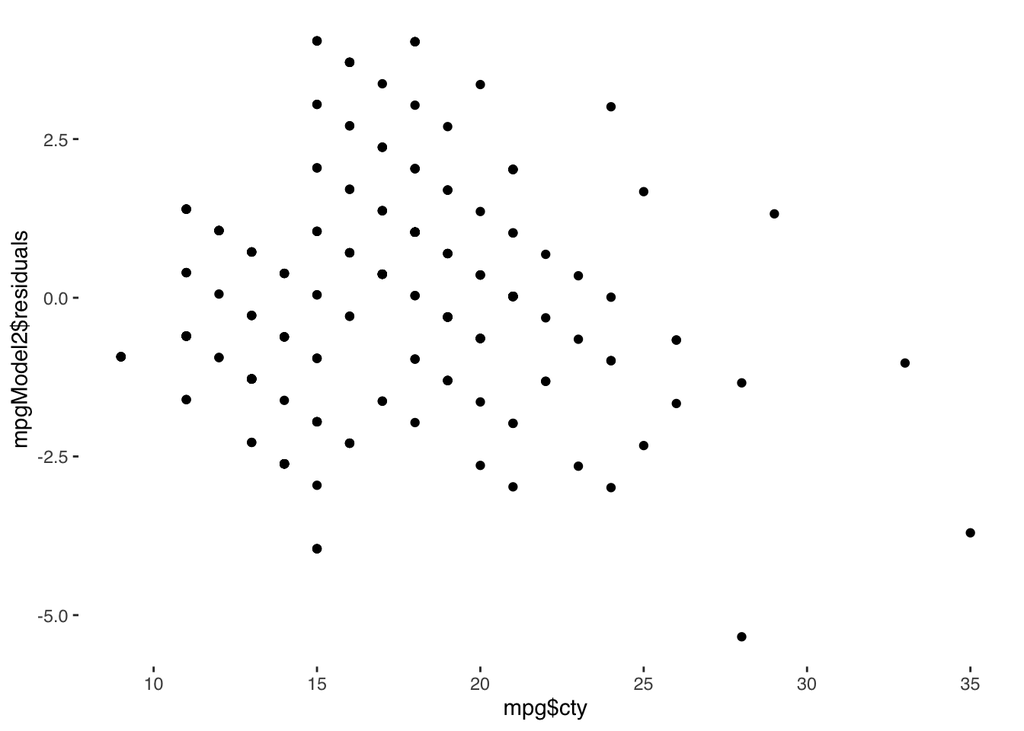

```r
mpgModel2 <- lm(mpg$hwy~mpg$cty)
qplot(mpg$cty, mpgModel2$residuals)
```

…

### Good residuals follow a normal distribution

### Ex: mpg, x=cty, y=hyw

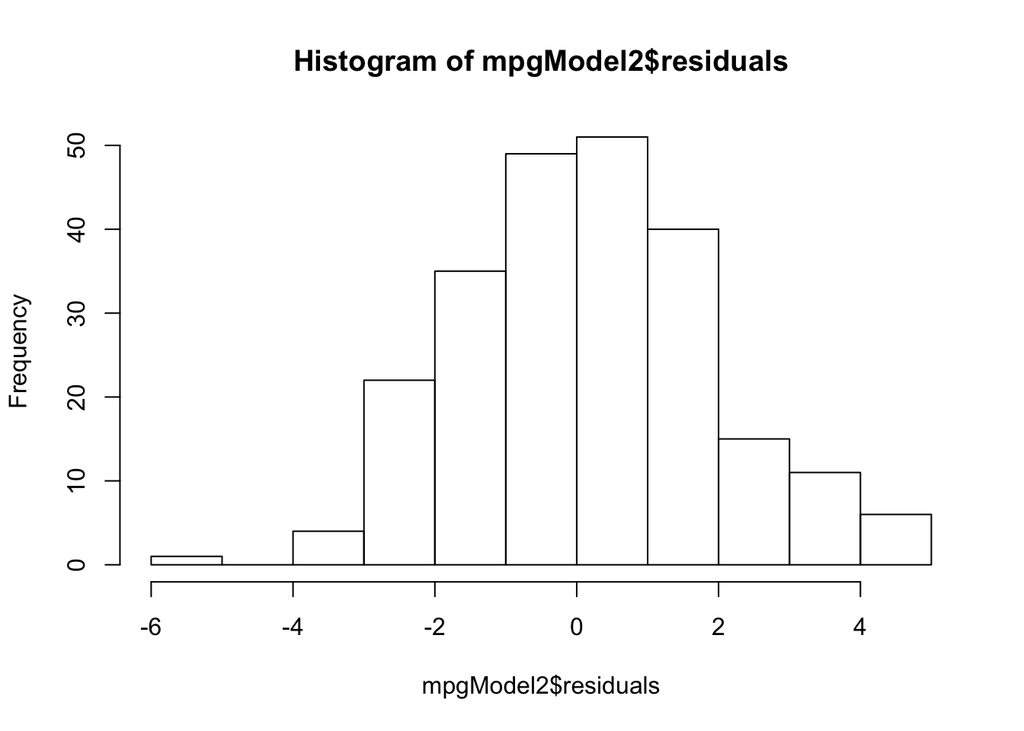

```r
hist(mpgModel2$residuals)
```

…

### Ex: mpg, x=displ, y=cty

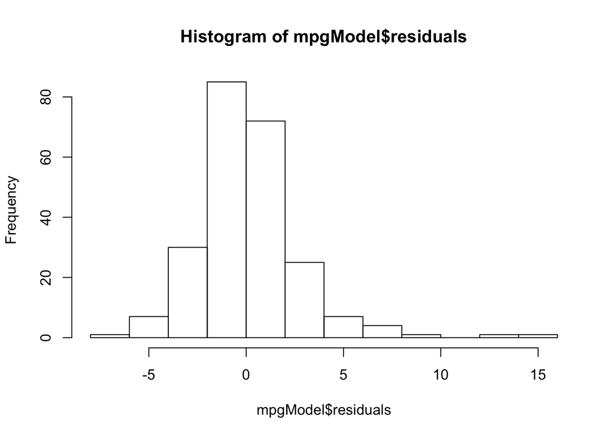

```r
hist(mpgModel$residuals)
```

Can see right skew…

# Wed March 3

## Evaluating the model (ctd)

So far:

- Effects of Outliers
- Residuals (resid plot and dist of the residuals)

Today:

- Coefficient of Determination, r^2, (R^2).

The coeff of det, r^2, tells us …

Discussion: …

Math is easy: literally (r)^2 !!

```
coef of det = (correl coeff)^2
```

### Ex:

Suppose that, in a dataset about 50 men, the correlation coeff between height and weight is computed to be r=0.76. In a linear model to predict weight based on height, compute and interpret the coef of det.

x = height y = weight

Compute:

```r
.76^2
```

```
## [1] 0.5776
```

Interpret: …

### Ex: mpg x=displ y=cty

```r
cor(mpg$displ, mpg$cty)
```

```
## [1] -0.798524
```

```r
(-.7985)^2
```

```
## [1] 0.6376022
```

Interpretation: …

## Ch 3 - Probability

### Two Defs

A random experiment/chance experiment/random process is any process that could result in two or more unknown outcomes.

Ex: Flipping a coin. Could be heads or tails, no way of knowing.

Ex: Rolling a dice. Could be 1,2,3,4,5,6, no way of knowing.

Ex: Select a random DU student, record their height.

Ex: Take a random sample of 50 DU students, and record the proportion of them that are Freshmen.

Goal: how likely/unlikely is any outcome? Probability! Two main definitions:

1. Classical/Theoretical Probability. …

Ex: Flip a “fair” coin. What’s the probability of seeing H?

Ex: Roll a dice. What’s the chance that a prime number shows on top? Prime numbers: 2, 3, 5.

2. Experimental/Relative Frequency Probability. …

Ex) An imprisoned mathematician flips a coin 10,000 times and observes 4,981 Heads.

### Law of Large Numbers

…

Good news! …

Important notes about the picture on p82: …

# Friday Mar 5

## Disjoint Events / Addition Rule

Two events A and B are disjoint (mutually exclusive) if …

### Ex:

Are the following events disjoint? Random process: roll a dice.

```
A = the event that an even shows on top
B = the event that a prime number shows
```

### ADDITION RULE:

If events A and B are disjoint, then:

```
 P(A or B) = P(A) + P(B)
```

Think: For disjoint events, “or” means “+”.

#### Ex: Roll a dice.

```
 A = event that an odd shows up
 B = event that a number GREATER than 5 shows up
```

Compute P(A or B)

## Not Disjoint Events / General Addition Rule

What if A, B have outcomes in common? Venn Diagram!

For ANY two events A and B:

```
...
```

Think: …

Q: What if we use this formula on disjoint events?

A: Not a probelm, since for disjoint A and B: …

### Ex: Roll a dice.

```
 A = event that an even shows up
 B = event that a prime shows up
```

Calculate P(A or B):

```
 ...
```

### Ex: Two way tables (Contingency Tables)

mpg data, comparing year vs drive type

4 = 4 wheel drive f = front wheel drive r = rear wheel drive

```r
table(mpg$year, mpg$drv) %>% addmargins()
```

```
##
##          4   f   r Sum
##   1999  49  57  11 117
##   2008  54  49  14 117
##   Sum  103 106  25 234
```

What’s the probability that a random car is either a 1999 model or has rear wheel drive?

### Deck of cards:

4 suits: diamonds, hearts, spades, clubs

Each suit has 13 cards:

2, 3, 4, 5, 6, 7, 8, 9, 10, J, Q K, A

All together: 52 total cards

There are two colors:

- All diamonds and hearts are red
- All spades and clubs are black

The following in each suit are “face” cars: J, Q, K

### Ex)

If a card is selected at random, what’s the probability that it’s either a face card or a red card?

## Probability Distribution

For a chance experiment, a probability distribution is:

- a list of all possible outcomes
- the probability for each

Usually, we’ll express it as a table.

Ex: Suppose we flip a coin twice, and record the number of heads (x). Construct a probability distribution for x.